# Principal Components Analysis

## 1 Factors with units

## Shocks with units: \(A=\Gamma D\)

From the Introduction, \(\mathbf x_t=A\boldsymbol\varepsilon_t\). But the shocks \(\boldsymbol\varepsilon_t\) have variance one and **no units**. So split \(A\) in two:

\[\mathbf x_t=A\boldsymbol\varepsilon_t=\Gamma\underbrace{D\boldsymbol\varepsilon_t}_{\mathbf f_t}=\Gamma\mathbf f_t\]

- \(D\) is diagonal. It turns the shocks into **factors** \(\mathbf f_t\) in km/h and tonnes.
- \(\Gamma\) says what **one unit** of each factor does to the data. Then \(S=\Gamma D^2\Gamma'\).

## Structural: the flights

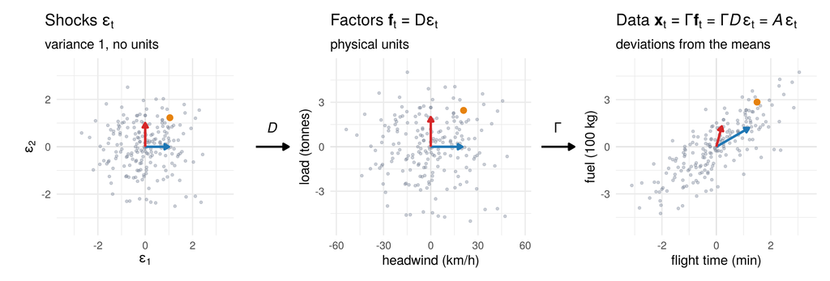

1. **Identify** \(A\). The manual’s fuel flow fixes the direction of the headwind arrow.
2. **Normalise** with one fact per factor. Each km/h of headwind adds 0.06 min, each tonne adds 0.1 min.

This gives sds of 20 km/h and 2 t, and 6 kg of fuel per km/h and 65 kg per tonne.

## Cholesky: a regression

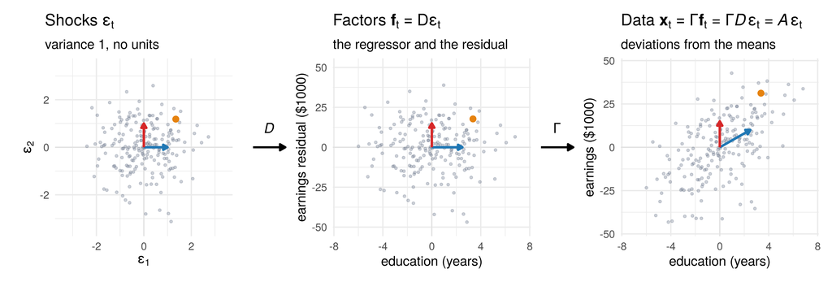

- Restriction \(a_{12}=0\). Normalisation: **ones on the diagonal** of \(\Gamma\).
- Factor 1 is education itself, with an sd of 2.5 years.
- Factor 2 is the earnings residual, with an sd of $15k. The slope \(\beta=4\) links the two.

## Symmetric root: roommates

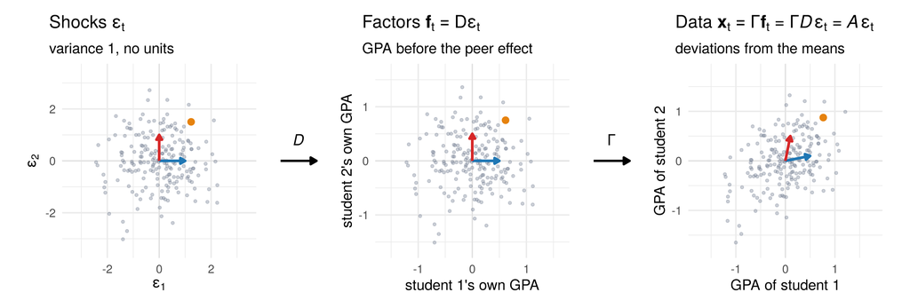

- Restriction \(a_{12}=a_{21}\). Normalisation: **ones on the diagonal** again.
- Factor \(j\) is student \(j\)’s own GPA before the peer effect, with an sd of 0.5.
- The peer effect is 0.2 in both directions.

## PCA: Coke and Pepsi

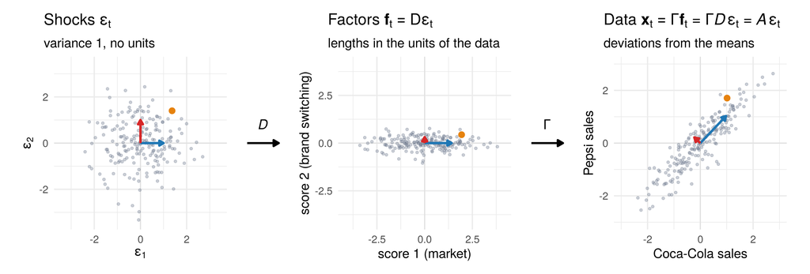

- Restriction: the first column is as long as possible. Normalisation: columns of \(\Gamma\) have **length one**.
- One unit of a factor then moves the data by a **distance of one**.
- The factor variances **add up** to the total variance, \(\operatorname{tr}(S)=\sum_j d_j^2\).

## Four normalisations

|  | restriction on \(A\) | normalisation of \(\Gamma\) | factors |
| --- | --- | --- | --- |
| Structural | the manual | one outside fact per factor | headwind (km/h), load (t) |
| Cholesky | \(a_{12}=0\) | ones on the diagonal | regressor, residual |
| Symmetric root | \(a_{12}=a_{21}\) | ones on the diagonal | each roommate’s own GPA |
| PCA | first column longest | columns of length one | scores (data units) |

\(D\) says how **important** each factor is, \(\Gamma\) how the variables **combine** them. A restriction picks \(A\), a normalisation splits it.

## 2 The direction of greatest variance

## Two arrows: who carries the variance?

[interactive chart not shown]

Every \(A\) with \(AA'=S\) fits the data. The total variance \(\operatorname{tr}(S)=\lVert a_1\rVert^2+\lVert a_2\rVert^2\) stays fixed, and turning the arrows only redistributes it. **PCA picks the angle at which \(a_1\) is longest.**

## Building the data: \(\mathbf x_t=\Gamma D\boldsymbol\varepsilon_t\)

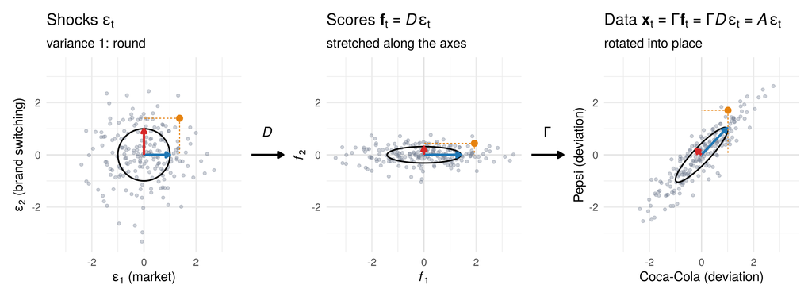

- At the PCA angle the arrows are perpendicular, so \(\Gamma\) is a **rotation**, \(\Gamma'\Gamma=I\).
- Read right to left. \(D\) stretches the shocks into the **scores** \(\mathbf f_t\), and \(\Gamma\) turns them into the data.

## Scores: take \(A\) apart one layer at a time

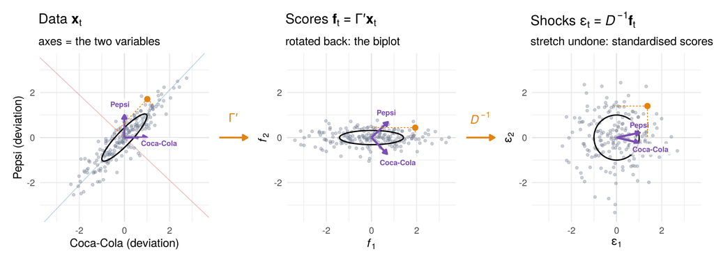

- Undo the rotation with \(\Gamma'\). The **scores** \(\mathbf f_t=\Gamma'\mathbf x_t\) are projections onto the components.
- Undo the stretch with \(D^{-1}\). This gives the **standardised scores** \(\boldsymbol\varepsilon_t\).
- The middle panel is the **biplot**. Each purple arrow is where one unit of a variable lands.

## Reading the biplot

The biplot draws \(\mathbf x_t=\Gamma\mathbf f_t\). Points are the scores, arrows are the rows of \(\Gamma\).

- **Point and arrow.** Project a point onto an arrow to read that variable’s value.
- **Distances.** Distances between points are Euclidean distances.
- **Arrow lengths.** Each arrow has length one when all components are shown. With fewer components, a short arrow means the variable lies mostly in the dropped ones.

The entries of \(\Gamma\) are the **weights** (`prcomp()$rotation`). With standardised scores, the arrows become the rows of \(A\), the **loadings**. `biplot(pc, scale = 0)` draws the scores version.

## Second arrow off: predictions

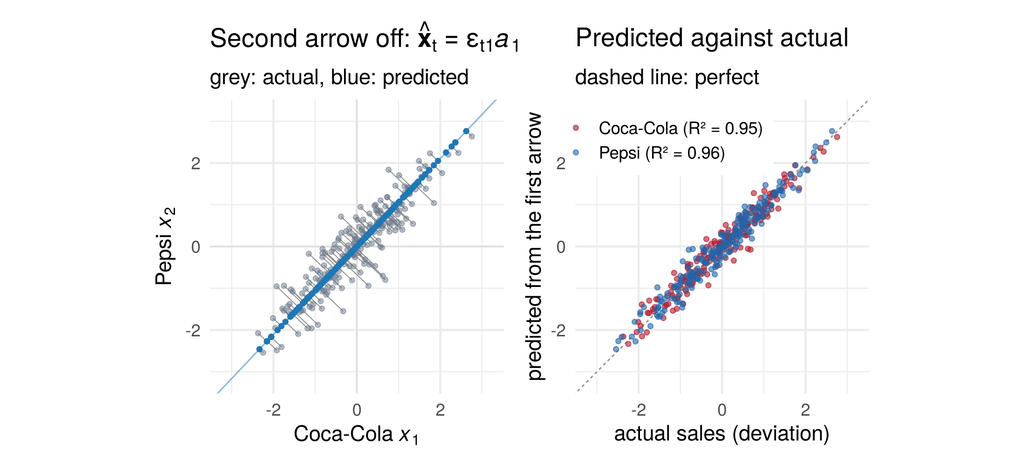

**Dimension reduction.** Drop the short arrow and keep one number per week, \(\mathbf x_t\approx f_{t1}\gamma_1\). This keeps 95% of Coca-Cola’s and 96% of Pepsi’s variance.

## The same answer from the data side

[interactive chart not shown]

Project the data onto any unit direction \(\gamma_1\). The scores \(f_{t1}=\gamma_1'\mathbf x_t\) have variance \(\gamma_1'S\gamma_1\), the same curve as \(\lVert a_1\rVert^2\).

## The principal components

\[\max_{\gamma_1}\ \gamma_1'S\gamma_1\quad\text{subject to}\quad\gamma_1'\gamma_1=1\]

- Without the length constraint there is no maximum. Doubling \(\gamma_1\) quadruples the variance.
- \(\gamma_2\) has the largest variance among directions **perpendicular** to \(\gamma_1\), and so on.
- The scores \(f_{tj}=\gamma_j'\mathbf x_t\) are the new variables.

By Pythagoras, the largest variance along the line means the **smallest perpendicular distances** to it.

## Not the regression line

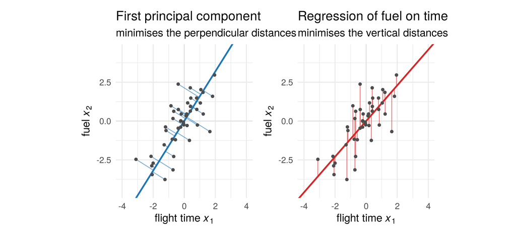

- Regression minimises **vertical** distances and treats one variable as given.
- PCA minimises **perpendicular** distances and treats both variables alike.

## 3 Eigenvectors and eigenvalues

## Vectors that stay on their line

[interactive chart not shown]

\(S\) moves the plane. The slider goes from doing nothing to applying \(S\).

- Points on the grey lines **leave** their lines.
- Points on the blue and red lines **stay** and are only stretched or squished. These are the **eigenvectors**, \(Sv=\lambda v\).

They point at 46.5° and 136.5°, the PCA directions, with \(\lambda=2.00\) and \(0.10\).

## Why the PCA directions are eigenvectors

\[S=AA'=(\Gamma D)(\Gamma D)'=\Gamma D^2\Gamma'\] \[S\Gamma=\Gamma D^2\Gamma'\Gamma=\Gamma D^2\quad\Rightarrow\quad S\gamma_j=d_j^2\,\gamma_j\]

- Each PCA direction is an **eigenvector** of \(S\), and its **eigenvalue** is the factor variance \(d_j^2\).
- The first component has the **largest** eigenvalue.

In general \(S=Q\Lambda Q^{-1}\). Because \(S\) is symmetric, \(Q^{-1}=Q'\), so \(S=Q\Lambda Q'\) is exactly the PCA split.

In R, `eigen(S)` replaces the slider. From here on \(\lambda_j\) is the variance of component \(j\).

## 4 Covariance or correlation matrix?

## PCA depends on the units

[interactive chart not shown]

Measure Pepsi in other units. The covariance-matrix arrows swing towards the variable with more variance. The correlation matrix gives the same answer for every unit.

## More variables: the states

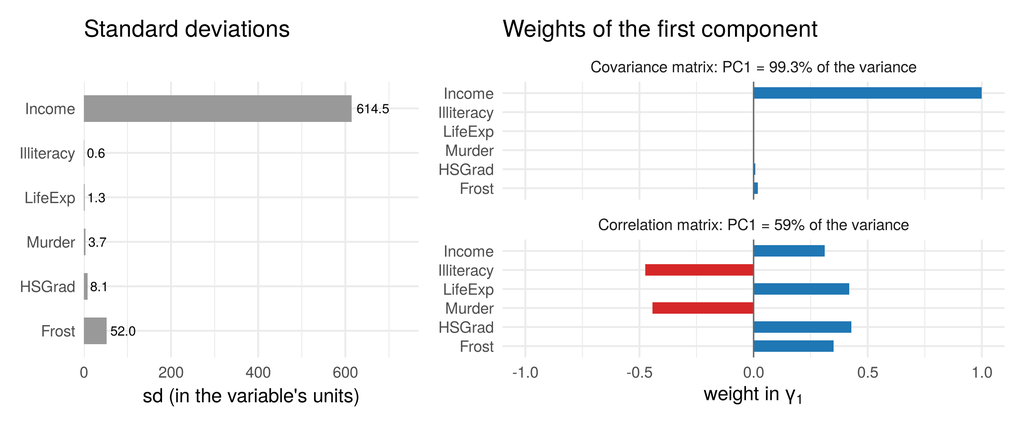

- With the covariance matrix, PC1 is income alone, because its sd is 614 dollars.
- With different units, **standardise** first. That is PCA of the **correlation matrix**.

## The states in a biplot

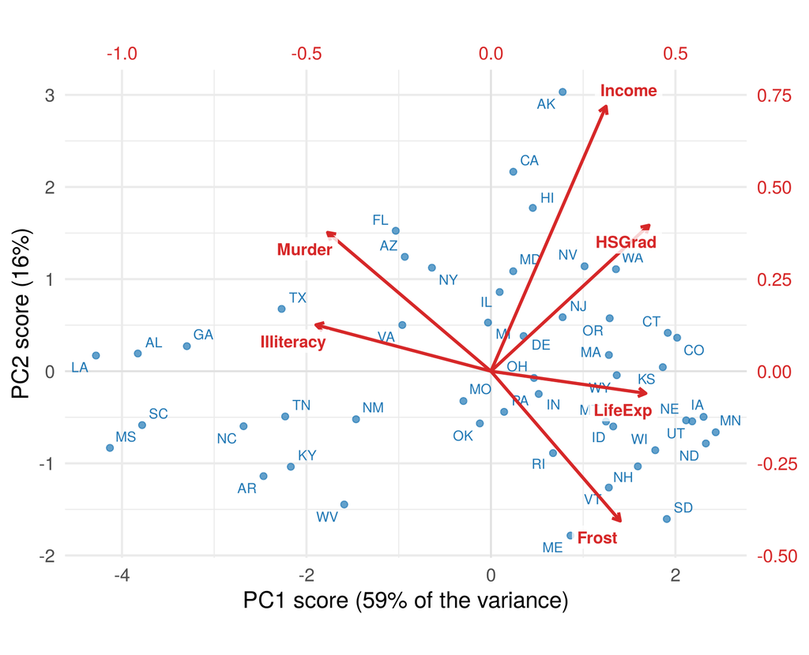

A horizontal arrow belongs to PC1, a vertical one to PC2. Opposite arrows form a **contrast**.

**PC1** (59%) contrasts illiteracy with life expectancy. Call it well-being.

**PC2** (16%) is mainly **income**.

Life expectancy has a short arrow, so the map shows it less well. These labels are interpretations, not facts.

## 5 How many components?

## Rules of thumb

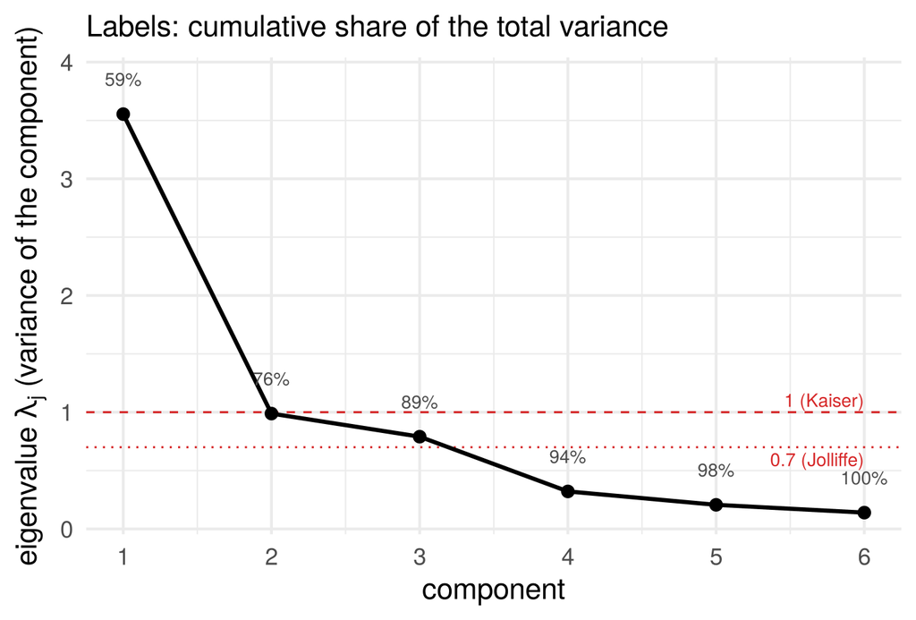

- Keep **70 to 90%** of the variance, or the eigenvalues **above average** (Kaiser 1, Jolliffe 0.7), or the components before the **elbow**.
- For the states the rules disagree. Choose with the purpose in mind.

## Reconstruction from \(m\) components

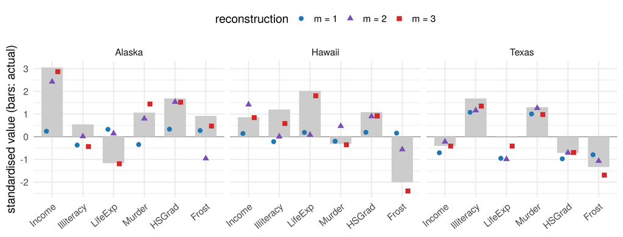

\(\hat{\mathbf x}_t=\sum_{j\le m}f_{tj}\gamma_j\). One component reconstructs Alaska and Hawaii badly.

## 6 What PCA is, and what it is not

## A convenient rotation, not the true shocks

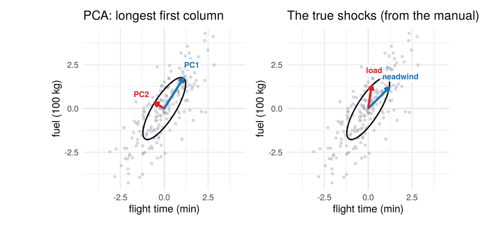

- For the flights, PC1 explains 91% of the variance but mixes headwind and load.
- “No mathematical method is, or could be, designed to give physically meaningful results” (Marriott 1974).

## Practical points

- Only **correlated** variables can be compressed.
- **Units** matter. Standardise unless all variables share a unit.
- **Outliers** move the components. Look at the data first.
- **Signs** are arbitrary, and components with close eigenvalues are unstable.
- In a **regression on components**, a low-variance component can still predict the outcome.

## 7 Two sets of variables

## Canonical correlation

Choose weights within each set that **maximise the correlation** between the two combinations. The next pair must be uncorrelated with the first.

\(R_1=0.71\): \[u_1\propto-0.98\,\text{Illiteracy}+0.19\,\text{HSGrad},\quad v_1\propto0.30\,\text{LifeExp}-0.95\,\text{Murder}\] \(R_2=0.37\): \[u_2\propto0.60\,\text{Illiteracy}+0.80\,\text{HSGrad},\quad v_2\propto0.75\,\text{LifeExp}+0.66\,\text{Murder}\]

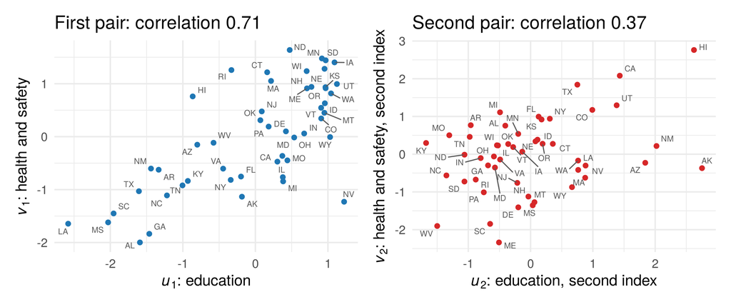

## Summary

## Takeaways

- \(A=\Gamma D\) splits each arrow into an importance and a direction. PCA gives the directions length one.
- PCA turns the arrows until the first carries the most variance.
- The components are the **eigenvectors** of \(S\), and their variances are the **eigenvalues**.
- With different units, use the **correlation matrix**. How many components to keep is a judgement.
- The **biplot** shows scores and variables together. Short arrows are poorly represented.
- PCA describes and compresses. It does not find the true forces.

PCA keeps the directions in which the data vary most, and drops the rest.